# Tarea1_Geomorfologia

Kevin Córdoba

2023-04-18

# **Geomorfologia**

### **Geomorfologia Eolica**

Los **procesos eólicos** dan pie a acontecer en regiones desérticas: desiertos cálidos y fríos, regiones semiáridas, zonas litorales: en las costas, regiones periglaciares, zonas distales de abanicos aluviales; estas en su mayoría son regiones secas y presentan escasez de vegetación, lo cual provoca que el viento pueda levantar, transportar y depositar sedimentos. Es por ello que el *objetivo* de este escrito es presentar a detalle los procesos eólicos que dan forma a modelados en el relieve tanto de tipo erosivo como sedimentario, en el cual se permite explicar la dinámica del viento como agente modelador. La **metodología** de trabajo fue realizar una revisión bibliográfica en internet, consultado libros y revistas. Lo que dio como resultado un artículo que identifica los diferentes procesos eólicos, así como sus formas resultantes (eólicas y acumulativas) y además, la identificación de las regiones que presentan las características adecuadas para que se produzcan tales *modelados eólicos*.

### **¿Qué estudia la geomorfología eólica**

La Geomorfología Eólica se encarga del estudio de los procesos, análisis de formaciones y estructuras de los depósitos eólicos, así como también información que estos puedan proporcionar sobre los climas del pasado.Estos procesos eólicos terrestres ocurren donde son abundantes las partículas pequeñas de ciertos materiales, también donde la vegetación es escasa o ausente, y los vientos son fuertes y frecuentes, por lo que éstos se limitan a desiertos cálidos y fríos, zonas costeras, a las regiones que bordean la actividad glacial, a regiones montañosas expuestas, zonas agrícolas y a sitios de construcción donde el suelo se encuentra descubierto; además, su intensidad se encuentra influenciada o depende de la fuerza, sincronización y dirección del viento, también por condiciones biológicas, la naturaleza y disponibilidad de sedimentos, humedad superficial, la vegetación y de la topografía de la zona.

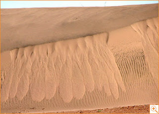

Los procesos eólicos son complejos y ocurren tanto a pequeñas como a grandes escalas, además, son difíciles de monitorear y a veces se complica probar algunas hipótesis tanto en el campo como en laboratorios; por lo que en muchas ocasiones estos procesos y modelados siguen siendo poco conocidos. Esta rama y los estudios modernos de los procesos y formas eólicas, han florecido de la mano de mejoras y avances en tecnología como los son las imágenes aéreas y satelitales.

A continuacion se presentan diferentes investigaciones para el mejor entendimiendo del tema

1. [Gutiérrez Elorza, M. (2001), Geomorfología climática](https://www.scielo.org.mx/scielo.php?script=sci_arttext&pid=S0188-46112002000100011)
2. [Geomorfologia do sistema sedimentar eólico de Paracaru - Ceará](https://pantheon.ufrj.br/handle/11422/7549)

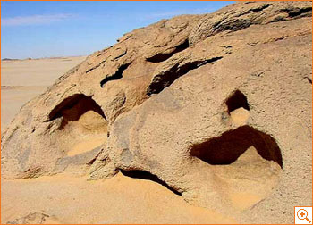